# Report for Project

张哲瑞 11712118  
荆若木 11712123

## Background introduction

Coronavirus disease 2019 (COVID-19) is an infectious disease caused by severe acute respiratory syndrome coronavirus 2 (SARS-CoV-2). It was first identified in December 2019 in Wuhan, China, and from that time spread globally, resulting in an ongoing pandemic. In Korean, The situation is also serious. What can we students do to help those people that are struggling in the pandemic? Thanks to the KCDC (Korea Centers for Disease Control & Prevention), a structured dataset based on the report materials of KCDC and local governments was provided by Korean researchers, Which enable us to do data analysis on these data, and make our efforts to help the world in our own way.

## Task1 Data statistics and data visualization

### Part I

```python
import pandas as pd
import matplotlib.pyplot as plt
import numpy as np
import seaborn as sns
from pandas.plotting import register_matplotlib_converters
register_matplotlib_converters()
```

```python
PatientInfo = pd.read_csv('PatientInfo.csv')
```

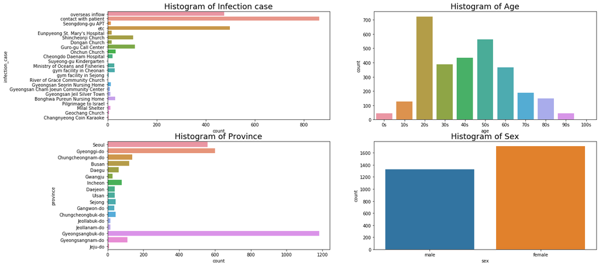

```python
_, [[ax1, ax2], [ax3 ,ax4]] = plt.subplots(2, 2, figsize=(20, 10))
#age_total = PatientInfo['age'].value_counts()
#sns.barplot(age_total.keys(), age_total.values, ax=ax2)
sns.countplot(y = PatientInfo['infection_case'], ax=ax1)
sns.countplot(PatientInfo['age'], order = ['0s','10s','20s','30s','40s','50s','60s','70s','80s','90s','100s'], ax=ax2)
sns.countplot(y = PatientInfo['province'], ax=ax3)
sns.countplot(PatientInfo['sex'], ax=ax4)
ax1.set_title('Histogram of Infection case', fontsize = 18)
ax2.set_title('Histogram of Age', fontsize = 18)
ax3.set_title('Histogram of Province', fontsize = 18)
ax4.set_title('Histogram of Sex', fontsize = 18)
```

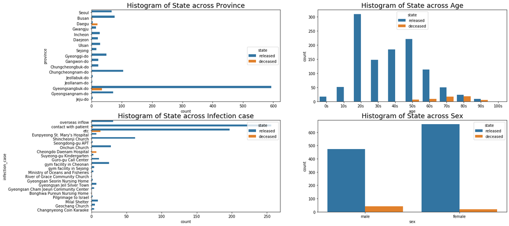

```python
PatientInfo_state_modify = PatientInfo[PatientInfo['state']!='isolated'].copy()
#state_sex = PatientInfo['state'].groupby(PatientInfo['sex']).value_counts()
_, [[ax1, ax2], [ax3 ,ax4]] = plt.subplots(2, 2, figsize=(20, 10))
sns.countplot(y='province', hue='state', data = PatientInfo_state_modify, ax = ax1)
sns.countplot(x='age', hue='state',order = ['0s','10s','20s','30s','40s','50s','60s','70s','80s','90s','100s'], data = PatientInfo_state_modify, ax = ax2)
sns.countplot(y='infection_case', hue='state', data = PatientInfo_state_modify, ax = ax3)
sns.countplot(x='sex', hue='state', data = PatientInfo_state_modify, ax = ax4)
ax1.set_title('Histogram of State across Province', fontsize = 18)
ax2.set_title('Histogram of State across Age', fontsize = 18)
ax3.set_title('Histogram of State across Infection case', fontsize = 18)
ax4.set_title('Histogram of State across Sex', fontsize = 18)
```

1. For the Histogram of state across province, we can see that most of the infected is deceased in Daegu.
2. For the Histogram of state across age, it is obvious that the deceased rate is higher when the age of the infected increases, since the elderly don't have such strong body like the youth.
3. For the Histogram of state across infection case, we can see that most of the infected is deceased in Cheongdo Daenam Hospital, which shows us the importance of keeping the medical personnel healthy.
4. For the Histogram of state across sex, although female are easier to get COVID-19 in Korean, but the deceased rate is lower for female comparing to male.

### Part II

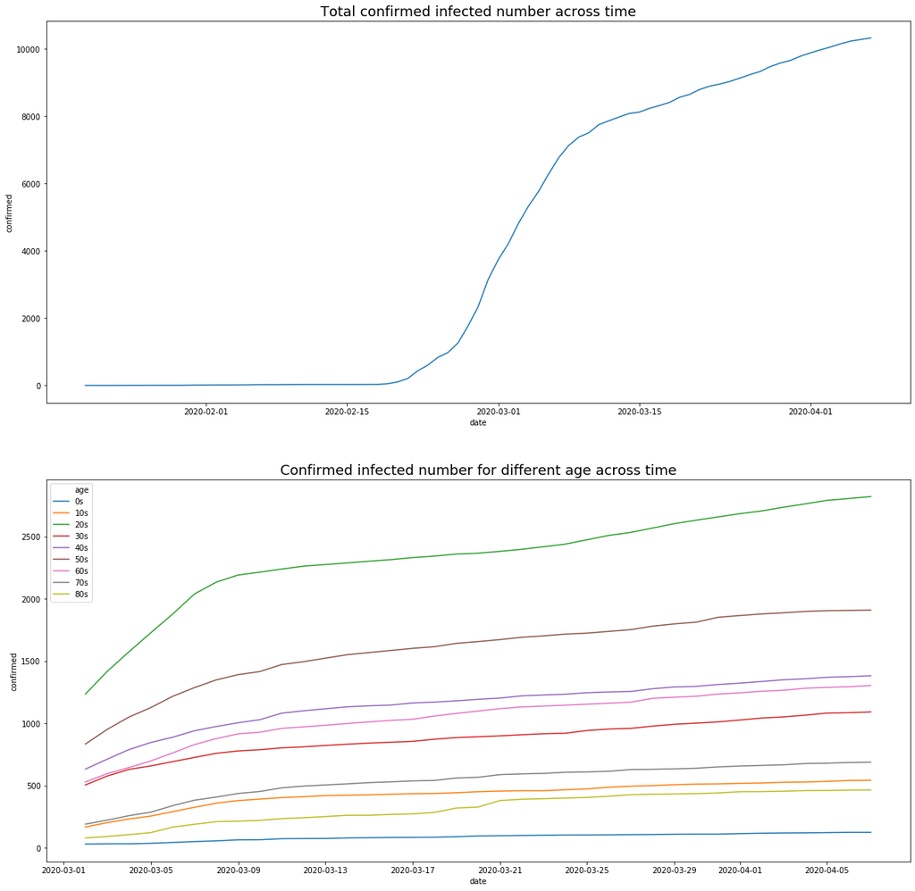

```python
_, [ax1, ax2] = plt.subplots(2, 1, figsize=(20, 20))
Time = pd.read_csv('Time.csv')
TimeAge = pd.read_csv('TimeAge.csv')
Time['date'] = pd.to_datetime(Time['date'])
TimeAge['date'] = pd.to_datetime(TimeAge['date'])
sns.lineplot(x = 'date', y = 'confirmed', data = Time, ax = ax1)
sns.lineplot(x = 'date', y = 'confirmed', hue = 'age', data = TimeAge, ax = ax2)
ax1.set_title('Total confirmed infected number across time', fontsize = 18)
ax2.set_title('Confirmed infected number for different age across time', fontsize = 18)
```

1. For the total confirmed infected number across time, there is burst at around 2020-2-20 due to some group infection cases and it won't grow slower until around 2020-3-10.
2. For the confirmed infected number for different age across time, we can see that the 20s has the both the most number and the fastest increasing speed.

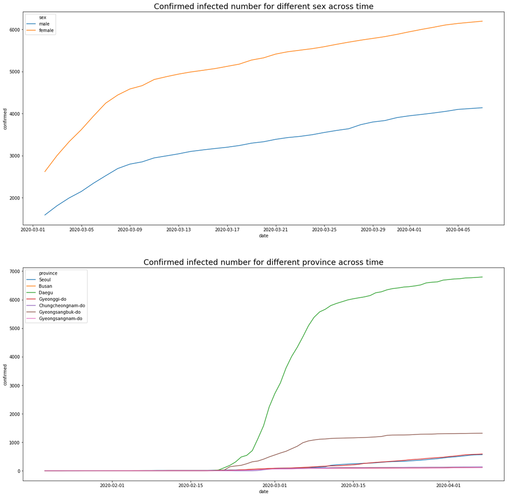

```python
_, [ax1, ax2] = plt.subplots(2, 1, figsize=(20, 20))
TimeGender = pd.read_csv('TimeGender.csv')
TimeProvince = pd.read_csv('TimeProvince.csv')
TimeGender['date'] = pd.to_datetime(TimeGender['date'])
TimeProvince['date'] = pd.to_datetime(TimeProvince['date'])
TimeProvince = TimeProvince[TimeProvince['province'].isin(['Seoul','Busan','Daegu','Gyeonggi-do','Chungcheongnam-do','Gyeongsangbuk-do','Gyeongsangnam-do'])]
sns.lineplot(x = 'date', y = 'confirmed', hue = 'sex', data = TimeGender, ax = ax1)
sns.lineplot(x = 'date', y = 'confirmed', hue = 'province', data = TimeProvince, ax = ax2)
ax1.set_title('Confirmed infected number for different sex across time', fontsize = 18)
ax2.set_title('Confirmed infected number for different province across time', fontsize = 18)
```

1. For the confirmed infected number for different sex across time, the data starts at 2020-3-2, which is not the start of the pandedmic, and the number of infected for female is larger than for male at first, and in the first 7 days after 2020-3-2, number for female grows faster than male, but after that the growing rates for male and female are almost the same.
2. For the confirmed infected number for different province across time, the shape of the confirmed infected number for Daegu across time is basically the same as the shape for the whole country, so we can conclude that Daegu is the provinces most affected by the pandemic.

## Task2 Prediction of the recovery time of patients

```python
from sklearn import tree
import sklearn.linear_model
from sklearn.model_selection import train_test_split
import sklearn.metrics as sm
import sklearn.preprocessing as sp
ReleasedPatientInfo = pd.read_csv('PatientInfo.csv')
Region = pd.read_csv('Region.csv')
ReleasedPatientInfo = ReleasedPatientInfo[~ReleasedPatientInfo['released_date'].isnull()]
ReleasedPatientInfo = ReleasedPatientInfo[~ReleasedPatientInfo['age'].isnull()]
ReleasedPatientInfo = ReleasedPatientInfo[~ReleasedPatientInfo['sex'].isnull()]
ReleasedPatientInfo['sex'].replace('male', 1, inplace=True)
ReleasedPatientInfo['sex'].replace('female', 0, inplace=True)
ReleasedPatientInfo['confirmed_date'] = pd.to_datetime(ReleasedPatientInfo['confirmed_date'])
ReleasedPatientInfo['released_date'] = pd.to_datetime(ReleasedPatientInfo['released_date'])
ReleasedPatientInfo['recovery_time'] = ReleasedPatientInfo['released_date'] - ReleasedPatientInfo['confirmed_date']
ReleasedPatientInfo['age'] = pd.to_numeric(ReleasedPatientInfo['age'].str[:-1]).astype("float")
ReleasedPatientInfo['recovery_time'] = pd.to_numeric(ReleasedPatientInfo['recovery_time'].dt.days).astype("float")
ReleasedPatientInfo = pd.merge(ReleasedPatientInfo, Region, how = 'inner', on = ['city','province'])
feature = ['age', 'sex', 'university_count', 'nursing_home_count', 'elderly_population_ratio']
X = ReleasedPatientInfo[feature]
y = ReleasedPatientInfo['recovery_time']
X_train, X_test, y_train, y_test = train_test_split(X, y, test_size=0.2, random_state=42)
model=sklearn.linear_model.LinearRegression().fit(X_train,y_train)
pred_y = model.predict(X_test)
pred_y = np.rint(pred_y)
test = list(y_test)
count = 0
for i in range(len(pred_y)):
    if (pred_y[i] <= test[i] + 5) and (pred_y[i] >= test[i] - 5):
        count += 1
print("Accuracy:",count/len(pred_y))
print("R2_Score:",sm.r2_score(y_test, pred_y))
print("Mean_Absolute_Error:",sm.mean_absolute_error(y_test, pred_y))
```

```
Accuracy: 0.5287958115183246
R2_Score: 0.0035867990443734232
Mean_Absolute_Error: 5.9214659685863875
```

```python
CPatientInfo = pd.read_csv('PatientInfo.csv')
Region = pd.read_csv('Region.csv')
CPatientInfo['state'].replace('isolated', 'NotReleased', inplace=True)
CPatientInfo['state'].replace('deceased', 'NotReleased', inplace=True)
CPatientInfo = CPatientInfo[~CPatientInfo['sex'].isnull()]
CPatientInfo = CPatientInfo[~CPatientInfo['age'].isnull()]
CPatientInfo['sex'].replace('male', 1, inplace=True)
CPatientInfo['sex'].replace('female', 0, inplace=True)
CPatientInfo = pd.merge(CPatientInfo, Region, how = 'inner', on = ['city','province'])
CPatientInfo['age'] = pd.to_numeric(CPatientInfo['age'].str[:-1]).astype("float")
feature = ['age', 'sex', 'university_count', 'elderly_population_ratio']
X = CPatientInfo[feature]
y = CPatientInfo['state']

X_train, X_test, y_train, y_test = train_test_split(X, y, test_size=0.2, random_state=42)
model = tree.DecisionTreeClassifier(criterion='entropy').fit(X_train, y_train)
pred_y = model.predict(X_test)
print(sm.classification_report(y_test, pred_y))
```

```
              precision    recall  f1-score   support

 NotReleased       0.87      0.86      0.87       377
    released       0.75      0.77      0.76       205

    accuracy                           0.83       582
   macro avg       0.81      0.81      0.81       582
weighted avg       0.83      0.83      0.83       582
```

## Task2

We do both regression and classification for Task2.  
We combine the information in *PatientInfo.csv* and *Region.csv*.

- Data preprocessing:
  - We remove the rows that with missing value in column 'released_date' to get the data of released patients. We also remove the rows that with missing value in column 'age' or 'sex'.
  - We convert column 'sex' from string to integer as "male" to 1, "female" to 0 in order to do regression.
  - We convert the column 'age' from string to integer. For example, '20s' to 20.
  - For regression, we convert the column 'confirmed data' and 'released date' from string to date format so that we can calculate the recovery time and add a new column 'recovery time'.
  - For classification, we convert the data in column 'state' of value 'isolated' and 'deceased' to 'Not released', since the number of 'deceased' is so few.
- Model constrction:
  - For regression: we use the basic linear regression model in sklearn.
  - For classification: we use the DecisionTree model in sklearn.
- Feature selection and model selection:
  - For feature selection:
    - For regression: We choose the feature ['age', 'sex', 'university_count', 'nursing_home_count', 'elderly_population_ratio']
    - For classification: We choose the feature ['age', 'sex', 'university_count', 'elderly_population_ratio']
- Model Evaluation:
  - For regression: We consider that the predicted recovery time in test case is true if it has within +-5 bias comparing to the true value.
    - Accuracy: 0.5287958115183246
    - R2_Score: 0.0035867990443734232
    - Mean_Absolute_Error: 5.9214659685863875
  - For classification: The result outputs in the above cell.
- Conclusion:
  - For regression: The result is pretty awful for regression, although we have tried many regression models. We think it is because the recovery time is more related to a person's physical condition and less related to neither the region education level nor elderly_population_ratio.
  - For classification: We consider whether the patient is released or not, and the result is pretty good. Since for the case of classification, the regional factors can play a more important roles. We can predict whether a patient is released or not with the information of his(or her) sex, age, the university count and the elderly_population_ratio in the region.

## Task3 Risk levels of the provinces

```
Risk levels of the provinces
Busan:Medium
Chungcheongbuk-do:Low
Chungcheongnam-do:Low
Daegu:High
Daejeon:Low
Gangwon-do:Low
Gwangju:Low
Gyeonggi-do:Medium
Gyeongsangbuk-do:Medium
Gyeongsangnam-do:Medium
Incheon:Low
Jeju-do:Low
Jeollabuk-do:Low
Jeollanam-do:Low
Sejong:Low
Seoul:Medium
Ulsan:Low

The Silhouette Score is: 0.520713312065021
The DBI is: 0.5221262717378834
```

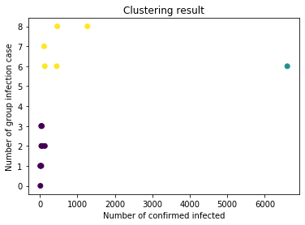

```python
from sklearn.cluster import KMeans
from sklearn.metrics import silhouette_score
from sklearn.metrics import davies_bouldin_score
Case = pd.read_csv('Case.csv')
Case['group'].replace('TRUE', 1, inplace=True)
Case['group'].replace('FALSE', 0, inplace=True)
province_group = Case.groupby(by=['province'])
province_total_num = Case.groupby(by=['province'])['confirmed'].sum().to_frame()
province_num_group_infect = Case.groupby(by=['province'])['group'].sum().to_frame()
province_case = pd.concat([province_total_num, province_num_group_infect], axis = 1)
province_case = np.array(province_case)
provinces = list(province_group.size().index)

province_case_std = sp.StandardScaler().fit_transform(province_case)

y_pre = KMeans(n_clusters=3, random_state=666).fit_predict(province_case_std)
risk = []
for i in y_pre:
    if i == 1:
        risk.append('High')
    if i == 2:
        risk.append('Medium')
    if i == 0:
        risk.append('Low')
    else:
        continue

print("Risk levels of the provinces")
for i in range(0, len(provinces)):
    print(provinces[i]+':'+risk[i])
print()

plt.scatter(province_case[:,0], province_case[:,1] ,c=y_pre)
plt.title("Clustering result")
plt.xlabel("Number of confirmed infected")
plt.ylabel("Number of group infection case")
silhouette = silhouette_score(province_case,y_pre,metric ='euclidean')
davies_bouldin = davies_bouldin_score(province_case,y_pre)
print("The Silhouette Score is: "+str(silhouette))
print("The DBI is: "+str(davies_bouldin))
```

## Task3

We use the information in *Case.csv* to define the region risk level by both the number of the infected and the number of group infection case.

- Data preprocessing:
  - We convert column 'group' from string to integer as "True" to 1, "False" to 0 in order to calculate the total number of group infection cases.
  - We group the data by 'province' to calculate the number of the infected and the number of group infection case in different provinces.
  - We use StandardScaler to scale the input data.
- Model constrction:
  - We use Kmeans to do the clustering.
- Model Evaluation:
  - The Silhouette Score is: 0.520713312065021
  - The DBI is: 0.5221262717378834
- Conclusion:
  - According to the number of the infected and the number of group infection case in different provinces, we can predict the risk level of province as follow:
    - Busan:Medium
    - Chungcheongbuk-do:Low
    - Chungcheongnam-do:Low
    - Daegu:High
    - Daejeon:Low
    - Gangwon-do:Low
    - Gwangju:Low
    - Gyeonggi-do:Medium
    - Gyeongsangbuk-do:Medium
    - Gyeongsangnam-do:Medium
    - Incheon:Low
    - Jeju-do:Low
    - Jeollabuk-do:Low
    - Jeollanam-do:Low
    - Sejong:Low
    - Seoul:Medium
    - Ulsan:Low

## Task4 Analysis of the location of cases and patients

```
The Silhouette Score is: 0.6410262967872564
The DBI is: 0.7049209611270012
```

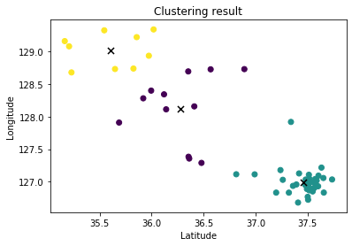

```python
Region = pd.read_csv('Region.csv')
PatientInfo = pd.read_csv('PatientInfo.csv')
PatientInfo = PatientInfo[PatientInfo['city']!='etc']
Region['pc'] = Region['province']+Region['city']
PatientInfo['pc'] = PatientInfo['province']+PatientInfo['city']
PC_num = PatientInfo['pc'].value_counts()
PCs = list(PatientInfo['pc'].value_counts().index)
for i in range(0, len(PCs)):
    if(PC_num[i] < 15):
        PCs = PCs[:i]
        break
Region = Region[Region['pc'].isin(PCs)]
model = KMeans(n_clusters=3, random_state=666).fit(Region[['latitude','longitude']])
center = model.cluster_centers_
plt.scatter(Region['latitude'], Region['longitude'] ,c=model.labels_)
plt.scatter(center[:,0],center[:,1],marker='x',s=50, c='BLACK')
plt.title("Clustering result")
plt.xlabel("Latitude")
plt.ylabel("Longitude")
silhouette = silhouette_score(Region[['latitude','longitude']],model.labels_,metric ='euclidean')
davies_bouldin = davies_bouldin_score(Region[['latitude','longitude']],model.labels_)
print("The Silhouette Score is: "+str(silhouette))
print("The DBI is: "+str(davies_bouldin))
```

## Task4

We use the information in both *PatientInfo.csv* and *Region.csv* to clustering the cities with their latitude and longitude to see whether we can find something interesting.